# Economic Epidemiology of Malaria and Economic Growth

Lakshmi K. Raut[^1]

2020-11-26

#### Abstract

This paper models the equilibrium dynamics of Malaria disease and growth in income. It incorporates utility maximizing private human as host behaviors regarding malaria related health care investments to build the disease dynamics and income growth. The paper contrasts how economic and biological epidemiology models differ in their predictions of dynamics of the disease and their effects on economic growth and in their prescriptions of public policies. The paper examines various public policies such as malaria awareness education program, provision of preventive cares to the poor through markets, and the timing of public malaria control programs, and the effects of such public policies on the dynamics of the disease and aggregate income.

JEL Classifications: I18, O4

Keywords: Epidemiology of Malaria, Disease Dynamics, Economic Development.

**Acknowledgement and disclaimer**[^2]

# 1 Introduction

Epidemiology is a discipline in medical science which mainly deals with the transmission and control of diseases. Individual behavior regarding investment in one’s health is an important determinant of the speed at which a disease spreads. Such individual behaviors are guided by economic calculations. Pure epidemiological models, however, do not incorporate such economic incentives. The purpose of this paper is to formulate an economic epidemiological model that explicitly formulates investment in health as a rational economic decision. The model is then used to study the effect of such individual investment decisions on aggregate disease and income dynamics and to estimate the economic burdens of the Malaria disease.

Malaria is prevalent among the poor in poorer countries, especially in tropical countries, with 80 percent of the disease incidence and fatality being concentrated in African countries. It affects an estimated 300 million people every year, resulting in about 2 million deaths a year. Fifty percent of the high infant death rate in developing countries is directly due to malaria, and the number of deaths is even higher when indirect causes are taken into account. In terms of lost DALYs and lost income and productivity growth, Malaria is a serious impediment to economic development of the poor in poorer countries. Children are most susceptible to malaria and without proper treatment, many die from it. Survivors acquire partial immunity, however, at a cost of higher morbidity and other health problems such as severe anemia and spleen diseases. Hence, malaria affects the productivity and income of surviving workers who have had the disease. In addition, being infectious, the disease creates negative external effects on other individuals. As studies by (Barlow 1967; Conly 1972; Kaewsonthi et al. 1988; Newman 1977, 1965),

show, malaria disease involves non trivial private costs due to lost earnings and preventive care, of social costs due to new infections. Additional literature can be found in the literature surveys by Hammer (1993) and Gomes (1993). Recent empirical studies by (Gallup and Sachs 1998a, 1998b; McCarthy, Wolf, and Wu 2000)

find substantial growth costs of malaria, especially in the African countries.

In this paper, I model the dynamics of the disease and its effect on aggregate income growth, incorporating utility maximizing private human behavior under a variety of public policy environments. An important part of this exercise is to identify a set of important parameters that describe the behavior of Plasmodium parasites, their vector carriers, and the behavior of victimized human hosts in order to better understand the disease dynamics and analyze the effect of disease control policies. My model differs from models in epidemiology literature by incorporating individual incentives to invest in malaria related health cares given his knowledge about the effect of the disease on health and productivity. My model is based on human capital approach to investment in health care. Two groups of models differ in their predictions of the dynamics of the disease and income, and in their implications for public policies - for example, the extent to which public control programs could be privatized through tax-subsidy policies or community level incentives, and the role of public education regarding the effect of malaria on productivity losses.

# 2 Biology of malaria parasites and health effects on human hosts

The malaria parasites need both human host and vector host to complete their reproduction process. I describe briefly only the important features of their life cycles that are relevant for our modeling purpose. Malaria disease results from biological developments of micro-organisms known as protozoal parasites after they are infused in human blood by mosquitoes during their blood meal. The parasite varies by type and in deadliness. The most notable strains are P. falciparum, P.vivax, P.ovale, and P.malariae – with the first type being the deadliest and most prevalent in Africa, and the last one being prevalent in most other tropical countries of Asia and South America.

The parasite’s life cycle is split between a human host[^3] and an Anopheline mosquito vector. Only 60 out of the 380 species of Anopheline mosquito can transmit malaria. Only the female mosquitos need blood meal from humans during hatching eggs, and thus involved in spreading of malaria.

During blood meal, the mosquito must inject anticoagulant saliva for an even flowing of blood meal. During that time, sporozoites from mosquito salivary gland are injected into human blood. After fighting and camouflaging the immune system of partially immuned humans, the survived sporozoites arrive in the liver within 45 minutes of the mosquito bite, and penetrate hepatocytes[^4], where they remain for 9-16 days. Through asexual reproduction or cloning, known as schizogony, the plasmodium multiply within the cells in the form of metrozoits. The timing of schizogony depend on the strain of the plasmodium: For instance schizogony is immediate for P.falciparum and P. malarie, and is delayed up to 10 months in the case P. vivax . After the cell divisions during schizogony, the cell will rupture and release the newly-formed daughter cells called merozoites. It is the synchronous destruction of many erythrocytes and the release of their contents that produce the alternating bouts of fever and chills characteristic of the disease. In the next subsection, I describe the detailed information on health effect at this stage.

Upon release, they reinvade red blood cells, and produce either micro and macrogametocytes, which are the male and female sex cells of the organism ready to be passed on to mosquito for cross fertilization, as described below; or they go through the process schizogony (cell multiplication) all over again and process continues until they produce micro and macrogametocytes, see Figure 2.1. they produce micro and macrogametocyte, which are the male and female cells ready to be passed on to mosquito for fertilization as described below.

Gametocytes produced in the primary attack seem to contain all the genetic information required to create sporozoites of several different activation times. The same seems true for gametocytes produced in relapses where the hypnozoites become activated. The immune system may produce antibodies to the gametocytes at this stage. Upon release, they penetrate red blood cells, and produce either merozoites or micro and macrogametocyte. Merozites, after some time lapse can transform into micro and macrogametocyte. See Figure 2.1.

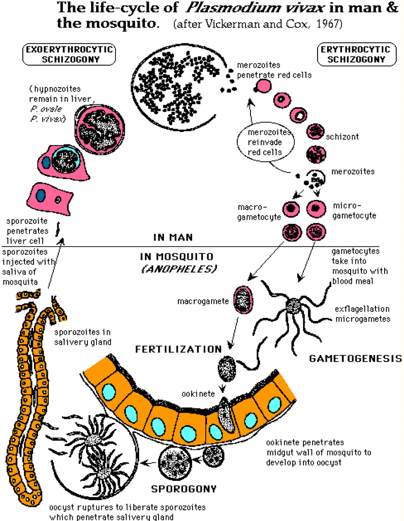

Figure 2.1: The life cycle of a Plasmodium organism.

The second phase in the life cycle of the plasmodium begins with a blood meal of mosquito. When a mosquito feeds on the blood, it intakes these gametocytes into its gut, where through random mating with the microgametocytes, the macrogametocytes are fertilized. After fertilization, the resulting ookinete enters the wall of a cell in the midgut of the mosquito after 18 to 24 hours, and there it transforms into an oocyst and then blasts. Many sporozoites are born within the oocyst. After the oocyst is raptured, the new sporozoites, then migrate to the salivary gland, where they lie up to 59 days, mature and turn into 1000 times more infective than when in the oocyst. In the gland the sporozoites wait for injection into another human host. The sporozoites are single cell micro organism of about 12$\mu$m long and 1$\mu$m across, with a single nucleus. One bite of a mosquito transfers only about 10% of its sporozoite load into the human blood stream. Plasmodium parasites seem capable of adapting to any suitable anopheline mosquito, given sufficient time and contact.

## 2.1 Symptoms and Health Complications

As the shizonts mature in the liver, human host gets high fever (it can above 41$^{o}$C), shivering, pain in the joints, headache, repeated vomiting, convulsions and coma. In severe cases of P. falciparum infection, the patient will have fits, coma and may die. Other health complications include cerebral malaria (unrousable coma), generalized convulsions, normocytic anaemia, renal failure, fluid, electrolyte and acid-base disturbances, pulmonary oedema, circulatory collapse, shock, disseminated intravascular coagulation, hyperpyrexia, hyperparasitaemia, and malarial haemoglobulinurea. These features may occur singly or in combinations. In kids, malaria may cause hypoglycaemia.

Malaria during pregnancy leads to very severe health consequences for both the mother and the child. For instance, it may lead to severe anemia and then to hemorrhage and ultimately to death, or to low birth weight and premature delivery. During pregnancy, a woman acquires reduced immunity against malaria and treatment for acute malaria is more complicated during pregnancy.

## 2.2 Treatment

- Preventive Care: insecticide impregnated mosquito nets (most cost effective) prophylactic drugs (expensive and meant for occasional use) Some substance from coconut tree, throwing those in ponds can kill mosquito larva (currently at development stage)
- Curative care: antimalarial drugs chloroquine oldest medicine but widespread drug-resistance Sulfadoxine/pyrimethamine Artemisnins, right now the drug of the last resort and P.falciparum, has not yet developed drug resistance
- Vaccines are at clinical testing stage. Different vaccines target different stages of life cycle of P.falciparum

# 3 The Basic Framework

Malaria affects an individual’s health, productivity and public health. The of an individual depend on his age, level of immunity against the disease acquired through prior incidence of malaria and of an individual, type of health care investments provided by parents when the individual was very young, and if he had malaria before[^5]. It is, however, analytically intractable to incorporate all these factors into an economic model of malaria. I will first consider a simplified model abstracting from many of these features to gain analytical insights. Later I will consider extensions that incorporate other features for the purpose of policy simulation exercises**.** The mathematical models of communicable diseases are generally formulated in continuous time. While for terminal diseases such as AIDS, it is somewhat easier to incorporate utility maximizing economic decision making in the continuous time framework (see, for instance models by (Kremer 1996; Philipson 2000), in the case of malaria disease, it turns out to be technically intractable. Therefore, I will formulate the model in discrete time.

## 3.1 The malaria disease dynamics

For analytical tractability, I assume that all malaria infections happen at the beginning of a period, and last for a fixed period of time $0<T<1.$ To cure an infection, it costs a fixed amount $x_{t}^{c},$ irrespective of the patient’s age, general health level, and prior contacts with malaria[^6]. I will use a binary (random) variable $\eta _{t}$ to represent the event of an individual’s contacting malaria infection in period $t,$ defined by $\eta_{t}=1$ if he contacts malaria infection and $\eta_{t}=0$ otherwise.

I assume that there is a fixed malaria curative package that can completely eliminate the likelihood of malaria if used before malaria infection season begins. The package costs a fixed amount $x_{t}^{p}$ in period $t.$ Let $\theta_{t}$ be a binary random variable denoting an individual’s decision in period $t$ to invest in this malaria prevention package, defined by $\theta_{t}=1$ if an individual invests in the package, and $\theta_{t}=0$ otherwise. The likelihood of malaria infection in period $t$ depends on the likelihood of bytes from mosquitoes carrying the infectious malaria plasmodiums (see section 2 for details on the biology of the infection). Thus the likelihood of an individual contacting malaria in period $t$ depends on three factors: (1) the size of the mosquito population carrying the malaria plasmodium, which is an increasing function of the malaria prevalence rate $i_{t}$ at the beginning of period $t$ which is the outcome of the malaria incident in period $t-1$; (2) individual decision to invest in malaria preventive care package, and (3) malaria preventive public policies such as spraying of DDT that may reduce the mosquito population. More specifically, without any public policy, the probability of an individual’s contacting malaria, that is, $\eta_{t}=1$ in period $t$ given his preventive health care investment plan $\theta_{t}$ is given by
$$\begin{equation}
p\left( \eta_{t}=1|\theta_{t}\right) =\left\{
\begin{array}
[c]{cc}
0 & \text{if }\theta_{t}=1\\
1-p\left( i_{t}\right) & \text{if }\theta_{t}=0
\end{array}
\right. \tag{3.1}
\end{equation}$$
In many economies, the public policies to spray DDT etc. that can reduce the mosquito population is a function of the infection rate rate$i_{t},$ and affect probability of malaria negatively as a function of infection rate $i_{t}.$ The proportion of population susceptible to malaria in period $t$ is then given by $\left( 1-\overline{\theta}_{t}\right) ,$ where $\overline {\theta}_{t}$ denotes the population mean of the random variable $\theta_{t}.$ I assume that we have a large population. By the law of large numbers, the percentage of population that is infected with malaria in period $t$ given the infection rate at the beginning of period $t$ in the previous period is given by

$$\begin{equation}
i_{t+1}=(1-\bar{\theta}_{t})\cdot(1-p\left( i_{t}\right) ) \tag{3.2}
\end{equation}$$

## 3.2 The economic dynamics

I assume that each individual lives a fixed number of periods $E$, that is, $E$ is the life expectancy, irrespective of his health shocks. Denote by $N_{t}$ the population size of the age group $a=1$ in period $t$. Assume that $N_{t+1}=\left( 1+n\right) N_{t},$ $N_{0}=1.$Denote by $\xi$ the number of adults of age $a>1$ in the population for each adult of age $a=1.$ $\xi$ can be thought as dependency ratio, and is given by $\xi=\sum_{a=2}^{E}1/\left( 1+n\right) ^{a-1}.$ The age structure $\xi$ depends only on $n$ and is constant when $n$ does not change over time. The total population in period $t$ is then given by $N_{t}\xi.$

An individual begins his adult life with an initial level of health capital $\tilde{h}>0,$ initial stock of wealth $k_{0}=0,$ and a schooling level $s.$ Productivity of a worker depends on his experience, assumed to be reflected in his age, his level of health capital, and his schooling level. Even though individuals enter their adult life differing only in their schooling level, over the life-cycle they differ in the level of health, and asset holdings, both of which are influenced by his choices of investment in health and financial assets, and the probabilities of encountering health shocks (malaria in our case) over the periods of his life.

I assume that malaria depletes vitality level more rapidly than the normal rate, and assume for simplicity these two rates are constant at all ages. More specifically, if an individual had a health stock $h_{a-1}$ at the beginning of period $\ t$ when he entered age $a,$ after the instantaneous malaria related health shocks at the beginning of period $t$, his health stock $h_{a}$ during period $t$ becomes
$$\begin{equation}
h^{a}=h^{a-1}\left( 1-\delta\left( \eta_{t}\right) \right) ,\ h^{0}
=\tilde{h} \tag{3.3}
\end{equation}$$
where the depreciation rate of health capital is $\delta\left(\eta _{t}\right)$, which depends on malaria related health shock $\eta_{t}$ in period $t$.

I assume that there is a continuum of schooling levels, which for simplicity is normalized to be in the unit interval $[0,$ $1].$ Let $f\left(s\right)$ be the probability density function, and $F\left(.\right)$ be the distribution function of the schooling level $s$ in the population. Assume that this distribution does not change over time. In each period, an individual might be infected with malaria from which he may survive, but he definitely loses some work time, duration of which may depend on the type of medical care he receives. Assume that the productivity level of a worker of age $a$, schooling level $s$ and health capital level $h$ is $e\left( a,s,h\right)$ units of efficiency labor which we take to be the worker of age $a=1,$ schooling level $s=0,$ and full health $\hat{h}$. The productivity level of the the efficiency worker in period $t$ is denoted by $b_{t}$ which grows over time at a endogenous rate $\gamma_{t}\equiv \gamma\left( i_{t}\right)$ during period $t$ as specified in equation below.

Let $r_{t+1}$ be the interest rate between period $t$ and $t+1,$ $w_{t}$ be the wage rate of a unit of efficiency labor in period $t$, and $i_{t}$ be the disease infection rate (or the proportion of mosquitoes infected) at the end of previous period, and hence, at the beginning of period $t$ before the malaria season. At the beginning of period $t,$ an individual of age $a$ has $k_{t}$ level of physical assets, and $h_{t}$ level of health capital. He decides to invest in health and physical capital sequentially as follows: He first decides $\theta_{t}$ by spending $\theta_{t}x_{t}^{p}$ amount in malaria preventive care package. His decision $\theta_{t}$ together with the prevalence rate of malaria $i_{t}$ during previous period and hence before the onset of malaria season in this period determine the likelihood of malaria health shock $\eta_{t}|\theta_{t}$ and his health capital $h_{t}$ in period $t$ as specified in equation , and the amount of lost productive time $\left( \eta_{t}|\theta_{t}\right) T,$ and malaria curative medical expenses $\left( \eta_{t}|\theta_{t}\right) x_{t}^{c}.$ After experiencing the health shock, the individual decides the amount of savings in physical capital $k_{t+1}$ for the next period. The Bellman equation of his choice problem is given by

$$\begin{equation}
V_{t}^{a,s}\left( k_{t},h_{t}\right) =\max_{\theta_{t},k_{t+1},c_{t}}
E_{\eta_{t}}u\left( c_{t}\right) +\beta\cdot V_{t+1}^{a+1,s}\left(
k_{t+1},h_{t+1}\right) \tag{3.4}
\end{equation}$$

$$\begin{equation}
c_{t}+\theta_{t}x_{t}^{p}+k_{t+1}+(\eta_{t}|\theta_{t})x_{t}^{c}
=(1+r_{t})k_{t}+w_{t}b_{t}e\left( a,s,h_{t}\left( 1-\delta\left(
\eta_{t|\theta_{t}}\right) \right) \right) \left( 1-(\eta_{t}|\theta
_{t})T\right) \nonumber
\end{equation}$$

For the last period of life,

$$\begin{equation}
V_{t}^{E,s}\left( k_{t},h_{t}\right) =\max_{\theta_{t}}E_{\eta_{t}}u\left(
c_{t}\right) \tag{3.5}
\end{equation}$$

$$c_{t}+\theta_{t}x_{t}^{p}+(\eta_{t}|\theta_{t})x_{t}^{c}=(1+r_{t})k_{t}
+w_{t}b_{t}e\left( E,s,h_{t}\left( 1-\delta\left( \eta_{t}|\theta
_{t}\right) \right) \right) \left( 1-T\left( \eta_{t}|\theta_{t}\right)
\right)$$

$$\begin{equation}
\Gamma_{t}^{a,s}\left( k^{\prime},h^{\prime}|k,h\right) =\text{ }\sum_{\eta
}\mathcal{I}\left( k^{\prime}-k_{t+1}^{a-1,s}\left( k,h,\eta_{t}|\theta
_{t}^{\ast}\right) ,h^{\prime}-h\left( 1-\delta\left( \eta_{t}\right)
\right) \right) \cdot p_{t}\left( \eta_{t}|\theta_{t}^{\ast}\right)
\end{equation}$$

where,where $\mathcal{I}\left( x,y\right) =0$ if $\left( x,y\right) \neq\left( 0,0\right)$ and $\mathcal{I}\left( 0,0\right) =1$, and $\theta_{t}^{\ast}\equiv\theta_{t}^{a,s}\left( k_{t},h_{t}\right) .$

$$\begin{equation}
\Gamma_{t}^{a,s}\left( k^{\prime},h^{\prime}|k,h\right) =
\begin{array}
[c]{cc}
p\left( \eta_{t}|\theta_{t}^{a,s}\left( k,s\right) \right) &
\begin{array}
[c]{c}
\text{if }k^{\prime}=k_{t+1}^{a-1,s}\left( k,h,\theta_{t}^{a,s}\left(
k,h\right) ,\eta_{t}|\theta_{t}^{a,s}\left( k,h\right) \right) \\
\text{and }h^{\prime}=h\left[ 1-\delta\left( \eta|\theta_{t}^{a,s}\left(
k,h\right) \right) \right] \text{ }
\end{array}
\\
0 & \text{otherwise}
\end{array}
\end{equation}$$

and *aggregate labor supply* is given by

$$\begin{equation}
L_{t}=N_{t}b_{t}\varphi_{t} \tag{3.8}
\end{equation}$$
where
$$\varphi_{t}\equiv\sum_{a,s,k_{t},h_{t},\eta_{t}|\theta_{t}^{a,s}\left(
.\right) }\bar{e}_{t}\left( a,s,k_{t},h_{t}\right) \cdot\pi_{t}
^{a,s}\left( k_{t},h_{t}\right) .$$
where

$$\bar{e}_{t}\left( a,s,k_{t},h_{t}\right) \equiv\sum_{\eta_{t}|\theta
_{t}^{a,s}\left( k_{t},h_{t}\right) }e\left( a,s,h_{t}\left(
1-\delta\left( \eta_{t}|\theta_{t}^{a,s}\left( k_{t},h_{t}\right) \right)
\right) \right) \left( 1-\left( 1-\theta_{t}^{a,s}\left( .\right)
\right) \left( \eta_{t}|\theta_{t}^{a,s}\left( k_{t},h_{t}\right) \right)
T\right) \cdot p\left( \eta_{t}|\theta_{t}^{a,s}\left( k_{t},h_{t}\right)
\right)$$

The productivity level of a unit of reference labor grows at the rate $\gamma_{t}$ as follows:
$$\begin{equation}
b_{t+1}=\left( 1+\gamma_{t}\right) b_{t},\text{ }b_{0}=1. \tag{3.9}
\end{equation}$$
where $\gamma_{t}$ is a function of new useful techonological knowledge $R_{t}$ generated in period $t$. These are generated endogenously in the economy as follows:
$$\begin{equation}
\gamma_{t}\equiv\hat{\gamma}\left[ R_{t}\right] ^{\mu},0\leq\mu\leq
1,\hat{\gamma}>0 \tag{3.10}
\end{equation}$$
where,
$$R_{t}\equiv\sum_{a,s,k_{t},h_{t}}\bar{\gamma}_{t}\left( a,s,k_{t}
,h_{t}\right) \cdot\pi_{t}^{a,s}\left( k_{t},h_{t}\right)$$

where

$$\bar{\gamma}_{t}\left( a,s,k_{t},h_{t}\right) \equiv\sum_{\eta_{t}
|\theta_{t}^{a,s}\left( k_{t},h_{t}\right) }\gamma\left( a,s,h_{t}\left(
1-\delta\left( \eta_{t}|\theta_{t}^{a,s}\left( k_{t},h_{t}\right) \right)
\right) \right) \left( 1-\left( 1-\theta_{t}^{a,s}\left( .\right)
\right) \left( \eta_{t}|\theta_{t}^{a,s}\left( k_{t},h_{t}\right) \right)
T\right) \cdot p\left( \eta_{t}|\theta_{t}^{a,s}\left( k_{t},h_{t}\right)
\right)$$

$\gamma\left( a,s,h\right)$ is the contribution to new social knowledge from a worker of age $a,$ schooling level $s,$ and health capital stock $h.$ This specification includes exogenous Harrod neutral technological change as a special case when we take $\mu=0.$ The exogenous productivity growth rate is then given by $\hat{\gamma}.$The term inside the bracket is the aggregate new research knowledge of period $t.$

A representative firm in each period $t$ uses labor in efficiency unit $L_{t}$ and capital $K_{t}$ to produce consumption and investment good of period $t$ using a constant returns to scale production function
$$\begin{equation}
Y_{t}=AK_{t}^{\sigma}\left( b_{t}L_{t}\right) ^{1-\sigma},0\,<\sigma<1,
\tag{3.11}
\end{equation}$$
where $b_{t}$ is the productivity level in period $t$ of a labor in efficiency unit. Denote by $\tilde{k}_{t}=\frac{K_{t}}{N_{t}b_{t}\varphi\left( i_{t}\right)}$ the capital-labor ratio in efficiency unit in period $t$. In the competitive market, the interest rate between period $t$ and $t+1$ is given by,

$$\begin{equation}
r_{t+1}=f^{\prime}\left( \tilde{k}_{t+1}\right) \tag{3.12}
\end{equation}$$
and the wage rate $w_{t}$ of a reference labor of one efficiency unit in period $t$ is given by,

$$\begin{equation}
w_{t}=f\left( \tilde{k}_{t}\right) -f^{\prime}\left( \tilde{k}_{t}\right)
\cdot\tilde{k}_{t} \tag{3.13}
\end{equation}$$

**Definition 3.1** Given an initial distribution of population $\pi_{0}^{a,s}\left( k_{0},h_{0}\right)$, an initial malaria infection rate $\hat{\imath}$ at the beginning of period $0$, a *malaria afflicted competitive equilibrium* is a sequence $\left\{ w_{t},r_{t}\right\} _{0}^{\infty}$ of wage rate and rental rate, a sequence of Malaria infection rate $\left\{ i_{t}\right\} _{0}^{\infty}$, a sequence of optimal policies for individuals $\left\{ \theta_{t}^{a,s}\left( k_{t},h_{t}\right) \right\} _{0}^{\infty}$, $\left\{ k_{t+1}^{a,s}(k_{t},h_{t},\theta_{t},\eta_{t}|\theta_{t} ^{a,s}\left( k_{t},h_{t}\right) )\right\} _{0}^{\infty}$, a sequence of value functions $\left\{ V_{t}^{a,s}\left( k_{t},h_{t}\right) \right\} _{0}^{\infty}$ a sequence of transition probabilities $\ \left\{ \Gamma _{t}^{a,s}\left( k_{t+1},h_{t+1}|\text{ }k_{t},h_{t},\theta_{t}\right) \right\}$, a sequence of labor productivity growth rate $\left\{ \gamma _{t}\right\} _{0}^{\infty},$ and a sequence of aggregate capital and labor $\left\{ K_{t},L_{t}\right\}_{0}^{\infty}$ such that equations (3.2) - (3.13) are satisfied.

It is not possible to compute these equilibrium analytically. I will use this framework to study properties of equilibrium numerically later. In the next section, I study the theoretical properties for two-period overlapping generations model.

# 4 A Two-period OLG model

To get some ideas about the properties of our model, I consider a simple two period overlapping generations model in which each individual lives for two periods. In period 1 he is young and makes all his decisions and in period 2 he is old and lives off his accumulated capital. For analytical tractability, I assume that individuals do not work in the second period and they are fully immuned in the second period. Denote by $c_{t}^{s,1}$, $c_{t+1}^{s,2}$, and $k_{t+1}^{s}$ respectively his consumption in the first and second period of life and his savings. Assume his utility function is of the form

$$\begin{equation}
U^{s}\left( c_{t}^{1,s},c_{t+1}^{2,s}\right) =u\left( c_{t}^{1,s}\right)
+\beta u\left( c_{t}^{2,s}\right) ,\text{ where }u\left( c\right)
=\frac{c^{1-\rho}}{1-\rho},\rho\neq1. \tag{4.1}
\end{equation}$$

The agent’s decision in period $t$ can be denoted by a binary variable $\theta_{t}$, taking value $1$ if he decides to invest the amount $\bar{x}_{t}^{p}$ in the preventive care package, and taking value $0$ otherwise. Agents live for two periods. In the first period he makes various decisions and in the second period he retires. I will drop the age suffix.

The budget constraint of the agent $\alpha=s$ in period $t$ can be rewritten as

$$\begin{equation}
c_{t}^{1,s}\left( \theta_{t},\eta_{t}|\theta_{t}\right) =y^{s}\left(
\theta_{t},\eta_{t}|\theta_{t}\right) -k_{t+1}. \tag{4.2}
\end{equation}$$
where $y^{s}\left( \theta_{t},\eta_{t}|\theta_{t}\right) \equiv\left[ \left( 1-\left( \eta_{t}|\theta_{t}\right) T\right) \left( 1-\left( \eta_{t}|\theta_{t}\right) H\right) e\left( s\right) -\theta_{t}x^{p})-(\eta_{t}|\theta_{t})x^{c}\right] b_{t}w_{t}$. The choice of $k_{t+1}$ is a standard inter-temporal utility maximization problem. The solution is given by
$$k_{t+1}^{s}\left( \theta_{t},\eta_{t}|\theta_{t}\right) =\mu\left(
r_{t+1}\right) \cdot y^{s}\left( \theta_{t},\eta_{t}|\theta_{t}\right) ,$$
where,
$$\mu\left( r_{t+1}\right) =\frac{\beta^{1/\rho}\left( 1+r_{t+1}\right)
^{\frac{1-\rho}{\rho}}}{1+\beta^{1/\rho}\left( 1+r_{t+1}\right)
^{\frac{1-\rho}{\rho}}}$$
is his income given his choice of malaria preventive care $\theta_{t}$ and the health shock $\eta_{t}|\theta_{t}$ that he encounters given his choice. of preventive health care $\theta$ the end of each period. The computation of demand for preventive care in period $t$ is equivalent to solving the following one period utility maximization problem: Given the prevalence rate of malaria $i_{t-1}$ the agent $\alpha=s$ chooses $\theta_{t}=1$ if and only if
$$\begin{equation}
u\left( c^{1,s}\left( 1,0|\theta_{t}=1\right) \right) \geq p\left(
i_{t}\right) \cdot u\left( c^{1,s}\left( 0,1|\theta_{t}=0\right) \right)
+\left( 1-p\left( i_{t}\right) \right) \cdot u\left( c^{1,s}\left(
0,1|\theta_{t}=0\right) \right) \tag{4.3}
\end{equation}$$

Which simplifies to the choice problem $\theta_{t}=1$ if and only if

$$\begin{equation}
\frac{1}{\left( 1-\rho\right) }\left[ 1-\frac{x^{p}}{e(s)}\right]
^{1-\rho}\geq\frac{p\left( i_{t}\right) }{1-\rho}+\frac{\left( 1-p\left(
i_{t}\right) \right) }{1-\rho}\cdot\left[ \left( 1-T\right) \left(
1-H\right) -\frac{x^{c}}{e(s)}\right] ^{1-\rho} \tag{4.4}
\end{equation}$$

Although we expect a higher variability, i.e., a higher value of $H$ for a higher schooling level, but for convenience, assume it to be constant. Notice that treating Eq. (4.4) as an equality, we can solve for $s$ implicitly as a function of infection rate $i_{t},$ which we denote by $\sigma^{\ast}\left( i_{t}\right)$. taking implicit derivative, it is easy to see that

$$\frac{d\sigma^{\ast}\left( i_{t}\right) }{di_{t}}=\frac{p^{\prime}\left(
i_{t}\right) \left( 1-\psi_{2}\left( s\right) \right) }{\psi_{1}^{\prime
}\left( s\right) -\left( 1-p\left( i_{t}\right) \right) \psi_{2}
^{\prime}\left( s\right) }<0$$
where, $\psi_{1}\left( s\right) \equiv\left[ 1-\frac{x^{p}}{e(s)}\right] ^{1-\rho},$ and $\psi_{2}\left( s\right) \equiv\left[ \left( 1-T\right) \left( 1-H\right) -\frac{x^{c}}{e(s)}\right] ^{1-\rho}$. This curve is shown in Figure 4.1, under the label with complete information. It is clear from equation Eq. (4.4) that given $i_{t},$ there exists a $\sigma^{\ast}\left( i_{t}\right)$ such that the right hand side of equation Eq. (4.4) is satisfied for all $s\in \lbrack\sigma^{\ast}\left( i_{t}\right) ,1].$ This curve is useful since it tells us at any period the population that will invest in the malaria preventive care package consist of those whose education level exceeds $\sigma^{\ast}\left( i_{t}\right) .$ It is important to note that the above is independent of all macroeconomic variables. It is now easy to calculate the proportion of young population who is susceptible to malaria during that period is given by susceptible to malaria
$$\begin{equation}
\left( 1-\bar{\theta}_{t}\left( i_{t}\right) \right) =1-\int_{0}^{1}
\theta_{t}^{s}\left( i_{t}\right) f\left( s\right) ds=\int_{0}
^{\sigma^{\ast}\left( i_{t}\right) }f(s)ds=F\left( \sigma^{\ast}\left(
i_{t}\right) \right) \nonumber
\end{equation}$$
Notice that in richer countries which will have higher densities at higher education levels will have relatively less population susceptible to malaria.

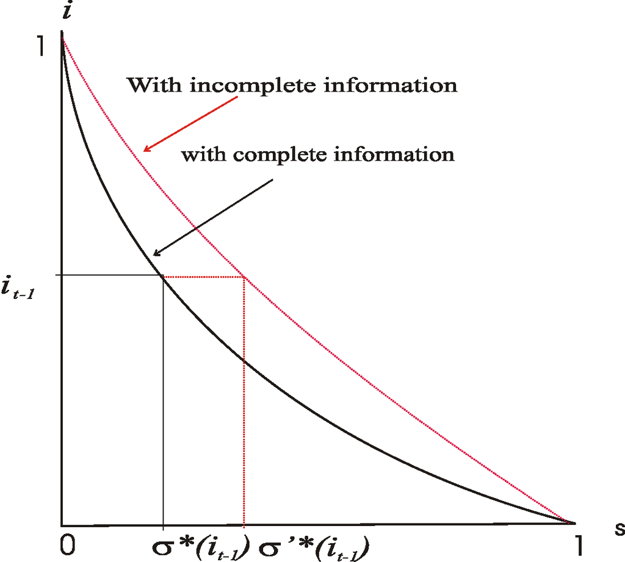

Figure 4.1: Implicit solution of Equation (4.4)

For an example, assume Mincer earnings function for a healthy individual of schooling level $s,$ i.e., $e\left(s\right) =e^{\mu_{0}+\mu_{1}s}$ where $\mu_{1}$ is the rate of returns from $s$ years of schooling. Equation Eq. (4.4) then simplifies to

$$s\geq\frac{\ln\left( x^{p}/\left( 1-\xi\left( i_{t-1}\right) \right)
\right) }{\mu}\equiv\sigma^{\ast}\left( i_{t-1}\right)$$

where $\xi\left( i_{t}\right) =\left[ p\left( i_{t}\right) +\left( 1-p\left( i_{t}\right) \right) \left( \left( 1-T\right) ^{1-\rho} \cdot\left( 1-H\right) ^{1-\rho}\right) \right] ^{1/\left( 1-\rho\right) }$. Note that $\sigma^{\ast}\left( {}\right)$ is a decreasing function as asserted in the more general case.

$$\left( 1-p\left( i\right) \right) =\left\{
\begin{array}
[c]{cc}
5\ast i^{2} & \text{if }0\leq i\leq.1/\sqrt{5}\\
1 & \text{otherwise}
\end{array}
\right.$$

Utilizing equation , the expected number of malaria infection, $i_{t+1},$which is also the malaria prevalence rate in period $t+1,$ is then given by
$$\begin{align}
i_{t+1} & =F\left( \sigma^{\ast}\left( i_{t}\right) \right) \cdot\left(
1-p\left( i_{t}\right) \right) .\label{eq18}\\
& =\left( 1+\rho\left( i_{t}\right) \right) i_{t}
\end{align}$$
where,
$$\left( 1+\rho\left( i_{t}\right) \right) i_{t}=F\left( \sigma^{\ast
}\left( i_{t}\right) \right) \cdot\left( 1-p\left( i_{t}\right) \right)$$
The shape of the function $\rho\left( i\right)$ is presumed to be as shown in Figure 4.2. This is a reasonable assumption because when infection rate $i$ is very low, the growth rate of infection $\rho\left( i\right)$ is also low and negative in spite of the fact that most people do not invest in preventive care, but a low rate of disease incidence is easier to contain within the given public health infrastructure; when the disease incidence rate $i$ is very high, say close to $1,$ most people invest in preventive care, and also there is little room for $i$ to grow and hence the growth rate $\rho\left(i\right)$ is very low and negative. At intermediate levels, $i$ can grow at higher rates. This is an important feature of the model which drives the results that follow, and it is useful to empirically estimate this shape.

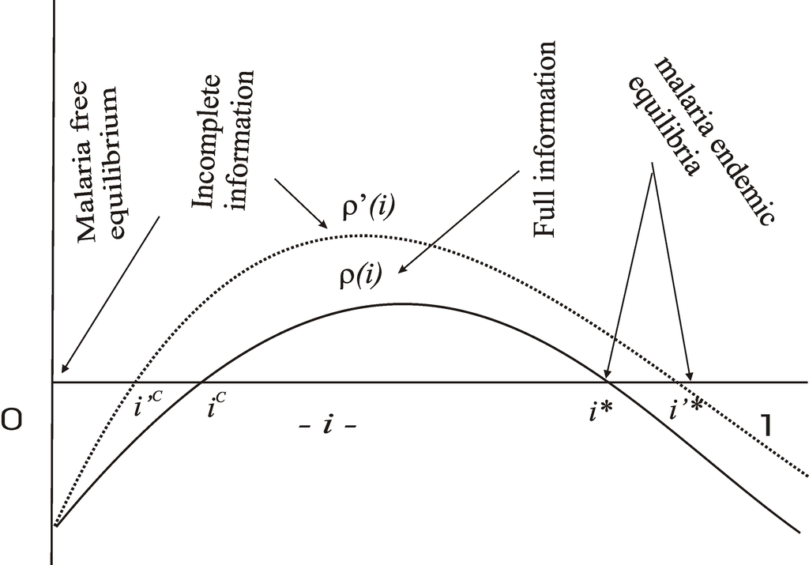

Figure 4.2: Transmission rate $\rho(i).$

Under the above assumption about the shape of $\rho\left( i\right)$, it is clear that there are two locally stable steady-state equilibria and another unstable steady-state equilibria. The locally stable equilibrium $i^{*}$ with strictly positive rate of malaria infection is said to be **malaria endemic equilibrium**, and the other locally stable equilibrium at zero level of infection rate is said to be a **malaria free equilibrium**. The unstable equilibrium is between these two equilibrium level of disease infection rates and it is labeled in Figure 4.2 as $i^{c}$. This unstable equilibrium rate determines a critical level of infection rate: If an economy has its infection rate below this critical level, eventually the economy will converge to the disease free equilibrium without any public intervention, and if it is above this critical level but below $i^{*},$ the rate of infection will rise over time until it settles down to the rate $i^{*}$; if the infection rate is above $i^{*}$ then the disease rate will decrease over time until it converges to the infection rate $i^{*}$.

Notice that the growth curve $\rho\left(i\right)$ depends on two important parameters – one is $p\left(0,i\right)$, which depends on climates and government policies towards sewage and DDT spraying, and the other one is $\sigma^{*}\left(i\right)$ which is determined by individual incentives to invest in malaria preventive care, which in turn also depends on $p\left(0,i\right)$ and the knowledge about the productivity effects of malaria infection.

Notice that a pure epidemiological model would postulate $i_{t+1}=\sigma\cdot\left(1-p\left(0,i_{t}\right) \right)$, where $\sigma$ is the fraction of population susceptible to malaria in period $t$, and would predict the dynamics of the disease quite differently than an economic epidemiology model in which individual/private economic decisions make $\sigma$ a decreasing function of $i_{t}$.

## 4.1 Malaria Awareness Education and its effects

Malaria causes serious anemia and other health complications which can permanently lower one’s productivity and leads to higher morbidity. A very few knows about these effects. In this section I study how the demand for preventive care is affected due to this incomplete information. What happens to dynamics when a government spends some resources to educate people about these permanent side effects of malaria on productivity loss and morbidity? What is the economic content of such malaria awareness education?

Suppose that only a fraction $n_{1}$of the population with higher education, $s>\bar{s}$, knows about the damaging permanent effect of malaria on productivity loss. Notice that for the unaware individuals, $\frac {h_{t}\left( s,1\right) }{h_{t}\left( s,0\right) }=1$, which is greater than $1-H$ on the right hand side of equation Eq. (4.4). Then it follows that the $i(s)$ curve for the population with incomplete information will be to the right of the one with complete information as shown in Figure 4.1 under the label “with incomplete information”. This means that given a rate of disease incidence, $i_{t-1},$ the set of population who invest on malaria preventive care will be lower under incomplete information than with complete information. This is shown in Figure 4.1 by $\sigma^{\prime\ast}\left( i\right)$. It then follows that the growth curve under incomplete information denoted by $\rho^{\prime}\left(i\right)$ shifts upward, leading to a higher equilibrium rate of malaria endemic disease rate denoted by $i^{\prime\ast}$ and lower level of the critical level denoted by $i^{\prime c}$.

If government spends some resources educating people to be aware of the real damaging effects of malaria, there will be a substantially lower disease incidence rate both along the transition dynamics and at the malaria endemic steady-state. An interesting policy implication of our analysis in this section is that for an economy with the number of unaware people such that the disease incidence rate $i$ is between the two critical levels, $i^{\prime c}$ and $i^{c},$ such an economy can eradicate malaria purely by public malaria awareness education. Even if their $i$ is above $i^{c},$ malaria awareness education can lead to higher demand for preventive care, and thus lower infection rates over time and at the steady-state. The total gains could outweigh the cost of such education, and it is an important empirical question.

## 4.2 Malaria and Economic Growth

In this section I will introduce the interaction between disease dynamics and growth in human capital and physical capital, and then study how the dynamics of disease constrains the growth path of the economy.

Given $i_{t}$, we know the population who invested in malaria preventive package, and the population who did not invest in malaria preventive package but got infected. Integrating over these populations, the optimal optimal asset holdings, we derive the aggregate capital of the next period to be as
$$K_{t+1}=L_{t}b_{t}w_{t}\mu\left( r_{t+1}\right) \left[ 1-Q_{1}\left(
\sigma^{\ast}\left( i_{t}\right) \right) -Q_{2}\left( i_{t}\right)
\right]$$
where, $\zeta\left( i_{t}\right) \equiv\int_{\sigma^{\ast}\left( i_{t}\right) }^{1}\frac{x^{p}}{e(s)}f\left( s\right) ds+\left( 1-p\left( i_{t}\right) \right) \int_{0}^{\sigma^{\ast}\left( i_{t}\right) }\left( T+H-TH+\frac{x^{c}}{e(s)}\right) f\left( s\right) ds.$

Thus we have

$$\begin{equation}
K_{t+1}=L_{t}b_{t}w_{t}\mu\left( r_{t+1}\right) \left( 1-\zeta\left(
i_{t}\right) \right)
\end{equation}$$
That is,

$$\begin{equation}
\hat{k}_{t+1}=\frac{\omega\left( \hat{k}_{t}\right) \mu\left( \hat{k}
_{t+1}\right) \left( 1-\zeta\left( i_{t}\right) \right) }{\left(
1+n\right) \left( 1+\gamma\left( i_{t}\right) \right) } \tag{4.5}
\end{equation}$$

## 4.3 The steady-state economic and disease equilibrium

Corresponding to two locally stable steady-state equilibria for malaria incidence rates $i=i^{*}>0,$ and $i=0$ in figure 4.2, there corresponds two long-run balanced growth rates of per capita income. The long-run growth rate of per capita income $y_{t}$ in these two types of equilibria are $\gamma\left( i^{*},s\right)$ at the malaria endemic equilibrium which is smaller than the growth rate at the malaria free equilibrium $\gamma\left( 0,s\right)$. In the short-run, the growth effect around these two equilibria will be even higher. For instance, around the disease free equilibrium, the disease infection rate will be falling and hence the lost time from infection will be declining, and contribution to social knowledge for productivity growth will be increasing over time. The scenario is exactly opposite around and below the malaria endemic equilibrium rate of infection $i^{*}$.

Some of the African countries and Asian countries might be stuck at the malaria endemic bad equilibrium and others in the malaria free good equilibrium. The point to note is that without government and foreign aid, the malaria disease prone tropical countries will be stuck in a malaria endemic equilibrium with low or negative growth in labor productivity and per capita income as compared to the malaria free non-tropical countries which will settle in a good equilibrium with no malaria and higher growth in productivity and per capita income. Two types of interventions that can move the malaria prone tropical economies from malaria endemic bad equilibrium to malaria free good equilibrium are: 1) external natural disasters such as extreme drug resistance or some natural evolutionary phenomena leading to high growth of disease incidence and malaria prevalence rate $i>\bar{\imath}$, so that there is a complete behavioral change for everyone to adopt to malaria prevention care; 2) since the government in these countries have limited resources, foreign governments may provide aid to subsidize the cost of malaria preventive care until the disease prevalence rate falls below the level $i^{c}$ in the diagram so that the momentum of the disease spread move downwards and ultimately converge to malaria free good equilibrium. In neither case, the malaria free good equilibrium will be sustained for ever. For instance, any external factors, such as migration of malaria parasite may ignite the disease spreading process. We name this phenomena as **Neo-Malthusian poverty trap.**

# 5 Policy Implications and conclusions

This leads to the Threshold Theorem of Kermack and McKendrick for public intervention for malaria control: in periods during which reproduction rate of the disease $R_{0}$ crosses the threshold level $1,$ public intervention is needed to increase $\bar{\theta}\left(.\right)$ in order to lower the value of $R_{0}$ to a level below $1,$ otherwise the disease will become epidemic.

Another important policy issue is to examine the effect of public education about true effects of malaria on productivity loss. I have shown that there are economies for which such public education can generate enough private demand for malaria preventive care such that eventually malaria can be eradicated. Even for other economies, public education will definitely boost private demand for preventive care which can postpone drug resistance, and lower the incidence of malaria infection in the steady-state and increase the rate of growth of per capita income both in the short-run and long-run. Whether these benefits of public malaria awareness education exceed the costs of providing such education is an empirical question need further investigation.

An important virtue of this framework is that one can compute the private and social burden of the disease in terms of lost earnings, lost lives, and lost rate of productivity growth. Currently I am putting together information to simulate this model calibrating the parameters of the model and introducing individual choices in curative care and taking its effects on drug resistance as observed in many parts of the world.

Still to incorporate: Francis (1997), Kermack and McKendrick (1927), Gonçalves, Ferrinho, and Dias (1996),Molineaux et al. (1980), Nchinda (1998), Strauss and Thomas (1998), World Health Organization and others (2000)

**Acknowledgements**

This paper is dedicated to my father’s memory who passed away on November 16, 2000, and to my mother’s memory who passed away on September 16, 2001 without medical care, facilities still not available in many villages in rural India. Earlier drafts were presented at the Far Eastern Econometric Society Meeting, Kobe, July 20-22, 2001, Western Economic Association Meeting, Seattle, June 30-July 2, 2002, Department of Biotechnology, Indian Institute of Technology, Kharagpur,India and Cal State Fullerton. Many thanks to the participants for many useful comments. Partial funding for this paper came from the World Bank Research Support Budget RPO 683-32. The findings, interpretations, and conclusions expressed in this paper are entirely those of the author. They do not necessarily represent the views of the World Bank, its Executive Directors, or the countries they represent.

# 6 Appendix

## 6.1 Optimal solution

Invest in preventative care, i.e., $\theta =1$ if and only if
$$\begin{equation}
\left[ 1-\frac{\bar{x}_{t}^{p}}{h_{t}\left( s,N\right) w_{t}}\right]
^{1-\rho }\geq p\left( 0,i_{t-1}\right) +\left( 1-p\left( 0,i_{t-1}\right)
\right) \cdot q\cdot \left[ \left( 1-T\right) \cdot \frac{h_{t}\left(
s,M\right) }{h_{t}\left( s,N\right) }\right] ^{1-\rho } \tag{6.1}
\end{equation}$$
Size of the population susceptible to malaria per unit of total population:
$$\begin{eqnarray*}
\left( 1-\overline{\theta }\left( i_{t-1}\right) \right) &=&1-\int \theta
\left( s\right) f\left( s\right) ds=\int_{0}^{\sigma ^{\ast }\left(
i_{t-1}\right) }f(s)ds \\
&=&\sigma ^{\ast }\left( i_{t-1}\right) \text{ under the assumption that }
f\left( .\right) \text{ is uniformly distributed.}
\end{eqnarray*}$$

## 6.2 Disease dynamics

The expected number of malaria infection, $i_{t+1}$ is given by
$$\begin{equation}
i_{t+1}=\left( 1-\sigma ^{\ast }\left( i_{t}\right) \right) \cdot p\left(
i_{t}\right) . \tag{6.2}
\end{equation}$$
The following form for probability of malaria :
$$\begin{equation}
\left( 1-p\left( 0,i_{t}\right) \right) =\left( 1+\rho \left( i_{t}\right)
\right) i_{t} \tag{6.3}
\end{equation}$$

Two steady state equilibria: malaria endemic equilibrium, and malaria free equilibrium. Pure epidemiological model would postulates: $ i_{t+1}=( 1-p( 0,i_{t}) )$

## 6.3 Malaria and Growth

Two period standard OLG set-up. $c_{t}^{1}\left( \omega \right)$, $c_{t+1}^{2}\left( \omega \right)$, and $A_{t}\left( \omega \right)$ Income during young age:
$$\begin{equation}
y_{t}\left( s,\omega |\theta \right) =\left( 1-T\left( \omega \right)
\right) h_{t}\left( s,\omega \right) \cdot w_{t}-\theta \cdot
x_{t}^{p}-x_{t}^{c}\left( \omega \right) . \tag{6.4}
\end{equation}$$
Budget constraints:
$$\begin{eqnarray}
c_{t}^{1}\left( \omega \right) &=&{\Large y}_{t}\left( s,\omega |\theta
\right) -A_{t}\left( \omega \right) \tag{6.5} \\
c_{t}^{2}\left( \omega \right) &=&\left( 1+r_{t}\right) A_{t}\left( \omega
\right) \nonumber
\end{eqnarray}$$
Applying the dynamic programming technique, get
$$\begin{equation}
A_{t}\left( s;\omega |\theta \right) =\left( 1-\alpha \right) \cdot {\Large y
}_{t}\left( s,\omega |\theta \right) \tag{6.6}
\end{equation}$$
We assume that $h_{t}\left( s,N\right)$ grows over time as follows:
$$\begin{equation}
h_{t+1}\left( s,N\right) =\left( 1+\gamma \left( i_{t};s\right) \right)
h_{t}\left( s,N\right) ,\;t\geq 0 \tag{6.7}
\end{equation}$$
Effective labor, $\tilde{L}_{t}=\bar{h}_{t}\cdot L_{t}.$ Assume that capital depreciate in one period. Then, we have
$$\begin{equation}
K_{t+1}=L_{t}\sum_{\omega =M,N}A_{t}\left( \omega \right) \tag{6.8}
\end{equation}$$
Capital labor ratio in efficiency unit $\tilde{k}_{t},$ has the following difference equation:
$$\begin{eqnarray}
\tilde{k}_{t+1} &=&\left\{
\begin{array}{ll}
\frac{\left( 1-\alpha \right) }{\left( 1+n\right) \left( 1+\gamma \left(
i_{t};s\right) \right) }\left( 1-\left[ x^{c}+\eta +T-\eta T\right]
i_{t}\right) \omega \left( \tilde{k}_{t}\right) & \text{ if }i_{t}<\bar{
\imath}\left( s\right) \\
\frac{\left( 1-\alpha \right) }{\left( 1+n\right) \left( 1+\gamma \left(
i_{t};s\right) \right) }\left( 1-x^{p}\right) \omega \left( \tilde{k}
_{t}\right) & \text{if }i_{t}\geq \bar{\imath}\left( s\right)
\end{array}
\right. \\
&\equiv &\Psi \left( \tilde{k}_{t},i_{t}\right) \text{ say} \tag{6.9}
\end{eqnarray}$$
Previous disease dynamics equation written:
$$\begin{equation}
i_{t+1}=\sigma ^{\ast }\left( i_{t}\right) \cdot \left( 1-p\left(
0,i_{t}\right) \right) .
\end{equation}$$
Steady state equilibrium growth rates: $\gamma \left( 0,s\right)$ and $\gamma \left( i^{\ast },s\right)$. Neo-Malthusian.

## 6.4 Policy Implications and conclusions

$i_{t+1}/i_{t}>1$ if and only $R_{0}=\left( 1+\rho \left( i_{t}\right) \right) \left( 1-\bar{\theta}\left( i_{t}\right) \right) >1,$ $R_{0}$ is known as the reproduction rate of the disease.

# References

Barlow, Robin. 1967. “The Economic Effects of Malaria Eradication (in Economics of Health).” Health-Malaria. *American Economic Review*.

Conly, Gladys N. 1972. “The Impact of Malaria on Economic Development.” *The American Journal of Tropical Medicine and Hygiene* 21 (5_Suppl): 668–74. https://doi.org/10.4269/ajtmh.1972.21.668.

Francis, Peter J. 1997. “Dynamic Epidemiology and the Market for Vaccinations.” Health-Malaria. *Journal of Public Economics* 63 (3): 383–406. https://doi.org/https://doi.org/10.1016/S0047-2727(96)01586-1.

Gallup, John L., and Jeffrey Sachs. 1998a. “Geography and Economic Development.” Malaria.

———. 1998b. “The Economic Burden of Malaria.” Malaria.

Gomes, Melba. 1993. “Economic and Demographic Research on Malaria: A Review of the Evidence.” Health-Malaria. *Social Science & Medicine* 37 (9): 1093–1108. https://doi.org/https://doi.org/10.1016/0277-9536(93)90248-3.

Gonçalves, Aldina, Paulo Ferrinho, and Francisco Dias. 1996. “The Epidemiology of Malaria in Prábis, Guinea-Bissau.” Malaria. *Memórias Do Instituto Oswaldo Cruz* 91 (1): 11–17. https://doi.org/10.1590/s0074-02761996000100002.

Hammer, Jeffrey S. 1993. “The Economics of Malaria Control.” Malaria. *The World Bank Research Observer* 8 (1): 1–22. https://doi.org/10.1093/wbro/8.1.1.

Kaewsonthi, Somkid, Narathip Cgabogaja, Chelliada Chamarukkula, and others. 1988. “Costs and Performance of Malaria Surveillance and Monitoring in Thailand: A Retrospective Study Based on Apportionment of Expenditure Under Budget Headings, Final Report of a Project Supported by the Tdr Social and Economic Research Component.” Malaria.

Kermack, W. O., and A. G. McKendrick. 1927. “A Contribution to the Mathematical Theory of Epidemics.” Malaria. *Proceedings of the Royal Society of London. Series A, Containing Papers of a Mathematical and Physical Character* 115 (772): 700–721. http://www.jstor.org/stable/94815.

Kremer, Michael. 1996. “Integrating Behavioral Choice into Epidemiological Models of Aids*.” Malaria. *The Quarterly Journal of Economics* 111 (2): 549–73. https://doi.org/10.2307/2946687.

McCarthy, Desmond, Holger Wolf, and Yi Wu. 2000. “The Growth Costs of Malaria.” Malaria. National Bureau of Economic Research. https://doi.org/10.3386/w7541.

Molineaux, Louis, Gabriele Gramiccia, World Health Organization, and others. 1980. “The Garki Project: Research on the Epidemiology and Control of Malaria in the Sudan Savanna of West Africa.” Malaria. http://apps.who.int/iris/bitstream/handle/10665/40316/9241560614.pdf?sequence=1&isAllowed=y.

Nchinda, Thomas. 1998. “Malaria: A Reemerging Disease in Africa.” Malaria. *Emerging Infectious Diseases* 4 (3): 398–403. https://doi.org/10.3201/eid0403.980313.

Newman, Peter. 1977. “Malaria and Mortality.” Malaria. *J. Amer. Stat. Assoc.*

Newman, Peter R. 1965. “Malaria Eradication and Population Growth: With Special Reference to Ceylon and British Guiana.” Malaria. In *Bureau of Public Health Economics. Research Series*. Vol. 10. University of Michigan. School of Public Health.

Philipson, Tomas. 2000. “Chapter 33 Economic Epidemiology and Infectious Diseases.” Malaria, Handbook of health economics, 1: 1761–99. https://doi.org/10.1016/S1574-0064(00)80046-3.

Strauss, John, and Duncan Thomas. 1998. “Health, Nutrition, and Economic Development.” Malaria. *Journal of Economic Literature* 36 (2): 766–817. http://www.jstor.org/stable/2565122.

World Health Organization and others. 2000. “WHO Expert Committee on Malaria: Twentieth Report.” Malaria. http://apps.who.int/iris/bitstream/handle/10665/42247/WHO_TRS_892.pdf?sequence=1&isAllowed=y.

[^1]: Visiting Fellow, CEHD, University of Chicago, 1126 E. 59th St., Chicago, IL 60637, USA, lakshmiraut@gmail.com
[^3]: An exception is the parasite, P.malarie, which may affect other higher primates.
[^4]: Hepatocytes make up 60-80 percent of the of the liver and perform protein synthesis, protein storage and transformation of carbohydrates, synthesis of cholesterol, bile salts and others, more importantly, the formation and secretion of bile.
[^5]: Malaria infection renders partial immunity to future malaria infection. However, the strength of immunity decreases over time. It should be noted that this immunity is achieved at a price such as increased morbidity and reduced health status and learning abilities.
[^6]: Individuals who contacted malaria in the past acquired partial immunity to malaria.